# Code

# Topics

1. Code chunks
2. Inline code

## What are code chunks?

- Specified place for code
- Executable
- Weaved between text
- May print output or create new variables, for example

```r
1993 + 2023
```

```
[1] 4016
```

```r
number=1993+2023
number
```

```
[1] 4016
```

## Anatomy of a code chunk

1. On each end of the code chunk: 3 *backticks*: `` ``` `` **
2. Curly brackets: *engine*: `{r}` or `{python}` **
3. Top of chunk: Code chunk options, with *hashpipe*: `#|`

````markdown
```{r}
#| label: cars-r
#| echo: false
mtcars %>%
  distinct(cyl)
```
````

````markdown
```{python}
#| label: car-py
#| echo: false
distinct_cyl = mtcars.drop_duplicates(subset=['cyl'])
```
````

** *not needed in a code cell in a Jupyter notebook!*

## Code chunk options

Useful [code chunk options](https://quarto.org/docs/computations/execution-options.html)

| Option | Description |
| --- | --- |
| `eval` | `Evaluate the code chunk.` |
| `echo` | `Include the source code in output` |
| `output` | `Include code output results (`true`, `false`, or `asis`)` |
| `warning` | `Include warnings in the output.`` |
| `error` | `Include errors in the output (continues execution if error present).` |
| `include` | `Catch all for preventing any output (code or results) from being included.` |
| `label` | `Please make sure to label your code chunks! It helps with debugging.` |
| `fig-cap` | `caption your figure` |
| `fig-width` | `width of the figure` |
| `fig-height` | `height of the figure` |

## Code Chunk Options

Options for *all* code chunks: include in `yaml` (top of the document).

For example…

```yaml
---
format: html
execute:
  echo: false
---
```

… hides all code in the output!

## Inserting Code Chunks

Option 1: Source editor: Type it out

Option 2: Visual editor: `Insert` > `Code cell`

Option 3: Shortcuts:

- **RStudio**: *Ctrl+Alt+I (*or **Cmd + Option + I** on Mac)

## Demo: echo option

`echo` hides (FALSE)/shows (TRUE) code and outputs results

**Code**

````markdown
```{r}
#| label: ex-orig
#| echo: true
x = 1:10; y = 11:20
plot(x, y)
```
````

**Output**

```r
x = 1:10; y = 11:20
plot(x, y)
```

[output not shown]

## Demo: echo option

**Code**

````markdown
```{r}
#| label: ex-hide-code
#| echo: false
x = 1:10; y = 11:20
plot(x, y)
```
````

[output not shown]

**Output**

## Demo: eval option

`eval` controls whether the code is actually executed (`TRUE`) or just displayed without running (`FALSE`).

**Code**

````markdown
```{r}
#| label: ex-orig
#| eval: true
x = 1:10; y = 11:20
plot(x, y)
```
````

[output not shown]

**Output**

## Demo: eval option

`eval` controls whether the code is actually executed (`TRUE`) or just displayed without running (`FALSE`).

**Code**

````markdown
```{r}
#| label: ex-not-run
#| eval: false
x = 1:10; y = 11:20
plot(x, y)
```
````

**Output**

`ex-not-run` Output:

```r
x = 1:10; y = 11:20
plot(x, y)
```

## Code Fold

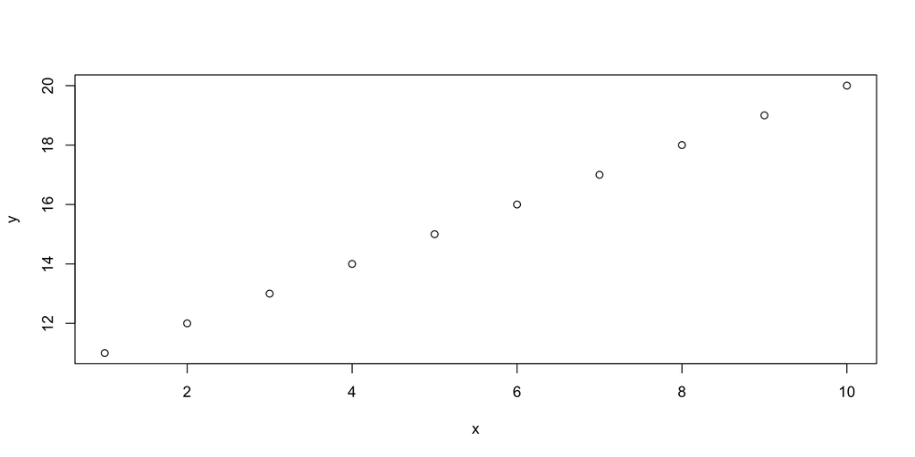

```r
x = 1:10; y = 11:20
plot(x, y)
```

# Code Chunk Exercise

# Inline Code

## Inline code: what & why?

Insert results or (quick) calculations into running text, without additional text formatting.

Why?

- report and describe results reproducibly
- minimizes errors: no manual copy-pasting results
- automatic updating when data or code changes

## Inline code

Enclose the *R* expression using `` `r ` ``.

**Code:**

```markdown
There are `r nrow(cars)` observations in our data.
```

**Output:**

There are 50 observations in our data.

**Important**

If using `Visual` or `Source` mode, be advised the *R* expression will only substitute the value held by the variable when the Quarto document is **rendered**. That is, the value contained within the expression only appears in the **output** file.

## Reference code chunk variables inline

**Code:**

````markdown
```{{r}}
#| label: calc-values
#| echo: false
x = 1:10
x_mu = mean(x)
x_sd = sd(x)
```
````

```markdown
The _mean_ of **x** is  `r x_mu` and
the _standard deviation_ is `r x_sd`.
```

**Output:**

The mean of **x** is 5.5 and the *standard deviation* is 3.02765.

## Inline code: how?

**In R**

```markdown
There are `r sum(penguins$Species=='Adelie')`
penguins of the Adelie species in the dataset.
```

```markdown
There are 152 penguins of the "Adelie" species in the dataset.
```